# The Cracked MLE Guide

mle

guide

How to become a world class Deep Learning Practitioner

Author

Saurav

Published

June 16, 2025

**One good decision will compensate for all previous failures like they’re nothing.**

[figure not shown]

**Just start. The journey to success often begins with a single step, but that first step can be the hardest to take. It’s easy to get caught up in the fear of failure or the desire for perfection.**

## Action

### Action Brings Results!

The magic you are looking for - *is in the work you are avoiding.* - You sit and wonder why you aren’t seeing success. - Whilst there is a pile of difficult tasks that you are avoiding that will push you closer to your goals.

The magic you are looking for ; is in *just doing things*. - **You gain so much more data by doing the thing than by thinking about doing the thing.** ~ Radek - **Advanced ideas can be extremely simple and effective when put in practice.** ~ Jeremy

### “Depth-First Procrastination” vs “Learning just in time”

I want to train a neural network.

So first I must learn the theory—read a textbook, [ankify it](https://borretti.me/article/effective-spaced-repetition). But to understand the math I must first learn probability and statistics in depth. Frequentism or Bayesianism? I heard really good things about [Jaynes](https://www.cambridge.org/core/books/probability-theory/9CA08E224FF30123304E6D8935CF1A99). Do I have the mathematical maturity? Maybe I should revise, say, set theory. The proofs in this textbook are very hard to read, so I rewrite them and make them more formal and refactor them into lemmas small enough to put into spaced repetition. They’re starting to look like [Fitch notation](https://en.wikipedia.org/wiki/Fitch_notation). Maybe I can write my proofs in first-order logic? Learning logic might give me a stronger foundation for doing proofs. But what is logic, really?

Somewhere in another Everett branch, a more sensible version of me is doing a PyTorch tutorial while I read Quine on what is or isn’t an ontological commitment in a first-order theory. I have six [SEP](https://plato.stanford.edu/) tabs open, and I still don’t know what a ReLU is.

I call it depth-first procrastination. You start with a high-level goal, and rather than taking the optimal route, a combination of intellectual curiosity and anxiety about standing on shaky foundations leads you to spawn subgoal after subgoal after subgoal, until you hit rock bottom and you find yourself doing some task so distantly related to the original goal you’re in another universe entirely. See also: [yak shaving](https://projects.csail.mit.edu/gsb/old-archive/gsb-archive/gsb2000-02-11.html), [OCD](https://medlineplus.gov/obsessivecompulsivedisorder.html).

I do this all the time: I learned to program because I wanted to write a program to write novels in. And while I never did do that, I did [invent my own programming language](https://austral-lang.org/). In college I spent more time [writing note-taking software](https://borretti.me/article/unbundling-tools-for-thought) than taking notes.

The upside of this is you learn self-reliance, and you learn foundational knowledge others might not. The downside is by the time you pop the stack back up to the top you’re old and dead.

And it’s always bullshit. Labouring in obscurity on some grandiose scheme for years is overrated. Tighten the feedback loop: trim the fat, ship, react, iterate. Do or die.

### **Things that aren’t doing the thing**

- Preparing to do the thing isn’t doing the thing.
- Scheduling time to do the thing isn’t doing the thing.
- Making a to-do list for the thing isn’t doing the thing.
- Telling people you’re going to do the thing isn’t doing the thing.
- Messaging friends who may or may not be doing the thing isn’t doing the thing.
- Writing a banger tweet about how you’re going to do the thing isn’t doing the thing.
- Hating on yourself for not doing the thing isn’t doing the thing.
- Hating on other people who have done the thing isn’t doing the thing.
- Hating on the obstacles in the way of doing the thing isn’t doing the thing.
- Fantasizing about all of the adoration you’ll receive once you do the thing isn’t doing the thing.
- Reading about how to do the thing isn’t doing the thing.
- Reading about how other people did the thing isn’t doing the thing.
- Reading this essay isn’t doing the thing.
- **The only thing that is doing the thing is doing the thing.**

One of my favorite lessons I’ve learnt from working with smart people:

- **Action produces information.**
- **If you’re unsure of what to do, just do anything, even if it’s the wrong thing. This will give you information about what you should actually be doing.

## **Sounds simple on the surface - the hard part is making it part of your every day working process.**

Motivation isn’t the key — Action is. You need action to get motivated, not the other way around. Sitting around and waiting for something to happen never got me.

**You should focus on systems (what you are doing to get the job) rather than goals (getting the job). The former is within your control, the latter is not.**

- Just Finish what you started. Finish the Fastai courses + Andrej’s NNs zero to hero + build projects. This is in your control. This will get you a job (not sitting and overthinking.)

### How to shut the inner voice

**Things I learnt by teaching others** ~ Umar Jamil - Most people struggle to learn not because they lack intellectual capacity. But because their inner voice keeps telling them they’re not smart enough. - **How to shut the inner voice : Work on Hard things and build confidence.** No other way.

## How to become expert at thing

1. Iteratively take on concrete projects and accomplish them depth wise, **learning “on demand”** ( i.e. don’t learn bottom up breadth wise)
2. Teach/summarize everything you learn in your own words.
3. **Only compare yourself to younger you, never to others.**

### 10,000 Hrs rule

- Beginners are always focused on - “what to do?”
- The Focus should be more on “How much you do”.
- Just pick the things where you can spend time and you’re interested in.
- You literally have to put in 10,000 hrs of work.
- It doesn’t even matter as much where you put it.
- You’ll iterate , You’ll improve and you’ll waste sometime.
- **If you devote yourself to *anything* diligently for ten years, that will make you an expert.**

> `Spend 10,000 hrs on deliberate effort and work, form a daily habit, and compare yourself to yourself from a year ago to track progress.`

### Keep Hacking !

1. **Snowball your Projects**
   - Keep on building projects. Just keep the momentum going…
   - Some of those projects may end upto nothing, But some of those projects will snowball into bigger and interesting projects.
   - Example: Andrej started with game programming tutorials → Started to love teaching → taught CS231n → Neural Nets zero to hero → LLM101n course
   - At OpenAI , a reddit chatbot project → when transformers came out → became GPT 1,2,3,4 …

[figure not shown]

2. **Put in the time (10,000 Hrs)**
- Don’t be nervous about - What am i working on ; Am i succeeding or failing ?
- Just count “how many hours you’re doing & everything adds up.
- Even the projects that fails / doesn’t snowball.. Those count to no. of hours I will spend developing my expertise.
- ( 8 hours a day) x (4 years) = 10,000+ hours
- Experience (10000+ hrs) makes you (World class) Expert !
3. **Keep the dopamine flowing**
- Your brain is a reward machine. It needs rewards.
- Keep the dopamine flowing → Work on projects. Publish your stuff.
- Projects get you to work on something end to end depthwise.
- In class, you learn it breadthwise, learning a lot of stuff , just in case you need it in future
- When you’re working on a project - You know what you need and you’re learning it on demand and you’re just trying to get it to work!
- Publishing it online , makes you think - how to make it really good.

## How to become like Neuralink

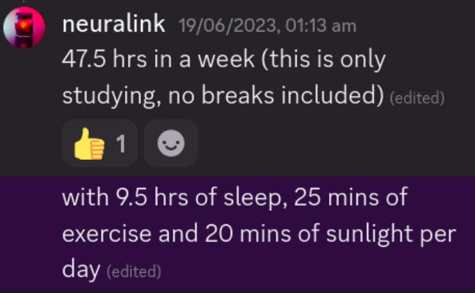

- **Timeblock every hour of next day with tasks , in the prior night. And Get Shit Done !! No matter what**

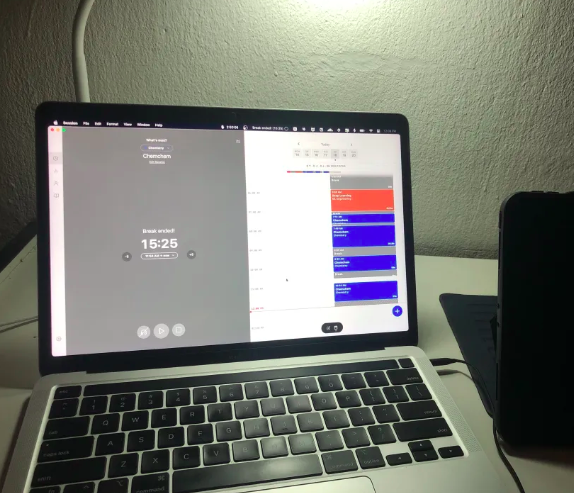

- **Just Do it Everyday.**

[figure not shown]

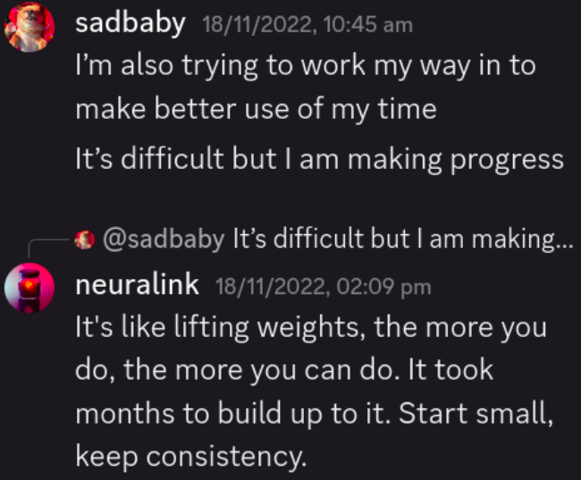

## How to become an ML engineer

- writing a ton of stuff from scratch,
- avoiding existing libraries as much as I could,
- reproducing other people’s results (eg: in papers)
- **Download a paper > Implement it > Keep doing this until you have skills**
- working on my own random passion projects that use the technology(AI).
- Find a project that requires efficiency and that would, without an efficient implementation, annoy the hell out of you. Loading that long array of images is ultra slow? Go and learn, on-demand, better algorithms and solve your problem.
- Also fun to hangout in discords : eg - Fastai, GPUMode, EluetherAI, , HuggingFace etc.

```
- You can just do things.
- Ignore the gate-keepers.
```

### How to Self Study ML without wasting time ~ Yoobin Ray

#### The Deep Work

- **eat, sleep, read research papers, reimplement paper baselines and novel models in PyTorch, repeat.**
- **I fought procrastination by not giving myself any other options** – I literally locked myself in the library study room without my phone many nights or I would deliberately go to a different campus without my phone.

### The most important skills for Machine Learning:

- Python
- Linux (env setup, ssh, moving files, editor)
- git
- pdb
- Creating good train - val - test splits
- Ability to scan papers for relevant information
- A learner mindset
- Clear writing
- Basic statistics
- Experiment design

#### The ML Engineer path

- Read Pytorch docs, a book, or a youtube tutorial on it
- Watch ANY build from scratch video
- Read and Implement papers from scratch untill you can do it without much help
- dissect how big real world companies are designing their ML systems (blog posts usually)
- the trick here: GO WIDE. Get good at multiple aspects of ML engineering—date engineering with spark, building models, fine tuning models, design CI/CD pipelines with the data orchestration (idk use airflow or stepfunction or something), understand the deployment process in production (MLOPS), dive into scalable architectures from Pinterest, Google, META, etc.

#### The ML Researcher path

- learn the intuition of classic trade offs in statistics like bias/variance, what happens when your dataset is noisy, etc.
- Learn ML theory using any good book/course
- Learn the early DL works before reading Attention is All you Need
- CNNs, NLP, LLMs, IT DOESN’T MATTER, choose whatever is cool to you in a given moment and just understand papers from a intuition perspective like “ah I see why they would add a final sigmoid activation at this step since we’re working with probabilities for multiple classes” or “ah I see why they actually need attention here because vanilla RNNs would just lose that context in its hidden states” etc. -> repeat with X amount of topics within DL
- The trick here: GO DEEP. Intuition. Intuition. Intuition. This is what I lack when reading research papers lately cuz I’m so optimized for engineering but if you wanna be a rock start researcher get that INTUITION!

# How to learn Programming

## George Hotz

- The only way to learn programming is…
- I have something I wanted to do , and I tried to do it.
- I am like…Okay..It would be nice…If the computer could do this thing..
- Thats how you learn - You just keep pushing on a project.

## Tips on becoming a better programmer (as an MLE)

- I now don’t see it as learning syntax, learning about programming paradigms or design patterns. For me, becoming better as a programmer now always starts with what I already know, even if it is very little, and learning on top of it via iteration / trying things out. Maybe
- writing something somewhere about what I learn to structure my thoughts (though in a class room I guess one can also talk to people which must be nice “. One thing I don’t do enough for sure is reading other people’s code - this is probably the best way to learn.
- Refactoring! I don’t think I ever heard this discussed in an academic setting, but this is one of the most important practices / skills. This book is great [https://refactoring.com](https://t.co/ZMgO6PyOpQ) - it explains the entire philosophy (probably no value in going too deep on the techniques when someone is just starting out, but the understanding that this is 99% of what writing maintainable code is about is invaluable.

# How to become good MLE

If you were starting out today what would you focus on and you wished you knew earlier in this DL journey ?

`Zach Mueller` - - **Get. Good. Software. Engineering. Skills.** - Same with math, strong code skills helps everything much easier in this space. - Do the Fastai courses. Follow Jeremy’s advice precisely. - Read all of Stas’ Book end to end, and watch all the DL from Foundations (fastai 2019 course)

- What are the most important things you learned from mistakes?
  - How to debug well, through brute force learning of it.
- Favorite Learning resources :
  - Python Distilled
  - Fastai Book + DL from Foundations (fastai course 2019)
  - [Stas Bekman Book](https://stasosphere.com/machine-learning/)
  - Clean Code (Uncle Bob)
  - A philosophy of software design (John Ousterhout)
  - The Art of Readable Code

# How to Learn

## Devoted to Reading and Learning

- “In my own life, I found that whenever I wasn’t sure what to do next, I would go and learn a lot, read a lot, talk to experts. I don’t know how the human brain works but it’s almost magical: when you read enough or talk to enough experts, when you have enough inputs, new ideas start appearing. This seems to happen for a lot of people that I know.”
- “When you become sufficiently expert in the state of the art, you stop picking ideas at random. You are thoughtful in how to select ideas, and how to combine ideas. You are thoughtful about when you should be generating many ideas versus pruning down ideas.”
- Andrew Ng thinks innovation and creativity can be learned — that they are pattern-recognition and combinatorial creativity exercises which can be performed by an intelligent and devoted practitioner with the right approach.

## Consistency beats Intensity (Always)

- Reading 2 research papers is a nice thing to do.
- But the power is not reading 2 research papers.
- Its reading 2 research papers per week for 1 year. Then you’ve read 100 papers.
- And you actually learn a lot when you read 100 papers.
- This sustained effort for a really long time - will make you a great DL practitioner. Not the bursts of efforts/all nighters on some days of the year…

## On Shortification of Learning & “How to actually Learn”

- Learning is not supposed to be fun. It doesn’t have to be actively not fun either, but the primary feeling should be that of effort.
- It should look a lot less like that “10 minute full body” workout and a lot more like a serious session at the gym. You want the mental equivalent of sweating.
- So for those who actually want to learn. Unless you are trying to learn something narrow and specific, close those tabs with quick blog posts. Close those tabs of “Learn XYZ in 10 minutes”.
- Consider the opportunity cost of snacking and seek the meal - the textbooks, docs, papers, manuals, longform. Allocate a 4 hour window. Don’t just read, take notes, re-read, re-phrase, process, manipulate, learn.

## [How To Understand Things](https://nabeelqu.co/understanding) - The Will To Think

- The smartest person I’ve ever known had a habit that, as a teenager, I found striking. After he’d prove a theorem, or solve a problem, he’d go back and continue thinking about the problem and try to figure out different proofs of the same thing. Sometimes he’d spend hours on a problem *he’d already solved*.
- I had the opposite tendency: as soon as I’d reached the end of the proof, I’d stop since I’d “gotten the answer”.
- Afterwards, he’d come out with three or four proofs of the same thing, plus some explanation of why each proof is connected somehow. In this way, he got a much deeper understanding of things than I did.
- I concluded that **what we call ‘intelligence’ is as much about virtues such as honesty, integrity, and bravery, as it is about ’raw intellect’**.
- Intelligent people simply *aren’t willing to accept answers that they don’t understand* — no matter how many other people try to convince them of it, or how many other people believe it, if they aren’t able to convince them-selves of it, they won’t accept it.

## You can internalize good intellectual habits that, in effect/return, “increase your intelligence”. ‘Intelligence’ is not *fixed*.

### Why don’t we think hard ?

- This quality of “not stopping at an unsatisfactory answer” deserves some examination.
- **One component of it is energy: thinking hard takes effort**, and it’s much easier to just stop at an answer that seems to make sense, than to pursue everything that you don’t quite get down an endless, and rapidly proliferating, series of rabbit holes.
- It’s also so easy to think that you understand something, when you actually don’t. So even figuring out *whether* you understand something or not requires you to attack the thing from multiple angles and test your own understanding.

## This requires a lot of intrinsic motivation, because it’s so hard; so most people simply don’t do it.

### the will to think

- The Nobel Prize winner William Shockley was fond of talking about “the will to think”:
- *Motivation is at least as important as method for the serious thinker, Shockley believed…***the essential element for successful work in any field was “the will to think”**_. This was a phrase he learned from the nuclear physicist Enrico Fermi and never forgot._ **“In these four words,” Shockley wrote later, “ Fermi distilled the essence of a very significant insight: A competent thinker will be reluctant to commit himself to the effort that tedious and precise thinking demands – he will lack ‘the will to think’ – unless he has the conviction that something worthwhile will be done with the results of his efforts.**_” The discipline of competent thinking is important throughout life…

`William Shockly , A researcher at Bell Labs got his Nobel Prize "for their researches on semiconductors and their discovery of the transistor effect."`

- But it’s not just energy. You have to be able to motivate yourself to spend large quantities of energy on a problem, which means on some level that **not understanding something — or having a bug in your thinking — bothers you a lot**. You have the drive, the will to know.
- Related to this is **honesty, or integrity:** a sort of compulsive unwillingness, or inability, to lie to yourself. Feynman said that the first rule of science is that you do not fool yourself, and you are the easiest person to fool. It is uniquely easy to lie to yourself because there is no external force keeping you honest; only *you* can run the constant loop of asking “do I really understand this?”.
- **This is why writing is important.** It’s harder to fool yourself that you understand something when you sit down to write about it and it comes out all disjointed and confused. **Writing forces clarity.**

[output not shown]

- My advice to people trying to understand something is: **go slow.** Read slowly, think slowly, really spend time pondering the thing. Start by thinking about the question yourself before reading a bunch of stuff about it. A week or a month of continuous pondering about a question will get you surprisingly far.
- And you’ll have a semantic mental ‘framework’ in your brain on which to then hang all the great things you learn from your reading, which makes it more likely that you’ll retain that stuff as well.
- This method is *far* more effective than just reading random things and letting them pass through you.
- The best thing I have read on really understanding things is the [Sequences](https://www.readthesequences.com/Book-I-Map-And-Territory), especially the section on Noticing Confusion.
- There are some mantra-like questions it can be helpful to ask as you’re thinking through things. Some examples:
  - But what exactly *is* X? What *is it*?
  - Why *must* X be true? Why does this *have to* be the case? What is the single, fundamental reason?
  - Do I really believe that this is true, deep down? Would I bet a large amount of money on it with a friend?

**The Neuroscience of “Think First”**

- Cognitive effort feels hard because it *is* hard. The prefrontal cortex, responsible for reasoning and decision-making, burns more energy per gram than nearly any other tissue in the body. That’s why our brains evolved habits, patterns, and automation: to conserve fuel.
- But deliberate thinking activates deeper learning.
- Research shows that *effortful retrieval* strengthens memory (Roediger & Karpicke, 2006).
- And when we struggle slightly before solving a problem, we encode it more deeply (Bjork’s “desirable difficulties”).
- So yes, it’s harder. That’s the point.

**How To Engage Your Brain (and Still Use ChatGPT)**

1. **Force yourself to think first.**

Before Googling or prompting ChatGPT, write down what you *think* the answer might be. Even if you’re wrong. This primes your brain.

2. **Use ChatGPT for reflection, not replacement.**

After solving something, ask ChatGPT to critique or optimize your solution. You’ll get feedback without outsourcing the core effort.

3. **Introduce friction by design.**

Block certain websites during deep work. Use pen and paper for design docs. Turn off autocomplete temporarily. Anything to make *you* do the work.

4. **Compress your knowledge.**

Write atomic notes on problems you’ve solved. One note = one concept. Add tags, links, and revisit often.

5. **Practice desirable difficulty.**

Mix up topics. Quiz yourself. Try coding problems without looking at docs. If it feels uncomfortable, you’re probably doing it right.

## How to study and learn really difficult subjects:

1. don’t panic. hard just means dense. it’s not impossible, it’s just packed. unwrap it slowly.
2. get a map before diving in. watch an overview video, read the table of contents, or skim the wikipedia page. you need context first.
3. use multiple sources. one book will confuse you, two will clarify, three will enlighten.
4. build intuition, not memory. visualize it. simulate it. code it. teach it to a friend or a wall with pen and paper.
5. tolerate confusion. you’ll feel dumb 90% of the time; that’s the price of learning something that rewires your brain.
6. connect it to reality. every abstract thing has a real-world analog. find it. relate it. ground it.
7. revisit the same topic after a week. mastery is not about reading once; it’s about returning after your brain has “chewed” on it.
8. don’t romanticize genius. smart people aren’t born knowing it. they just survived longer in the confusion phase.
- the truth is; learning hard stuff isn’t about intelligence. it’s about :
- Willingness to learn
- Curiousity
- Tenacity
- Consistency
- you stay long enough in the fog until it clears.

# Radek Osmulski

## Life changes , OR how the Fastai course went from being too high level to too low level from my perspective

- I remember taking the fastai course for the first time.
- *“OMG this is so high level, how is this even learning? Where are the derivatives?”*
- That was at a time when I **studied** machine learning.
- I didn’t compete at Kaggle. I didn’t have an ML job. I watched lectures, read books and papers, pondered set theory and the construction of real numbers, I didn’t even realize that PyTorch (or anything else with autograd) existed and I wrote code like [this](https://github.com/radekosmulski/10_neural_nets).
- Fast forward 5 years to this week’s lecture. Having **worked** in ML for the last 4 years or so.
- *“OMG this is so low level. Ahhh so this is how we calculate the bias term, and this is where we stick `with torch.no_grad()`. Ahhh, I see.”* I found this experience quite surprising What is the meaning of all this?
- On one hand, it might be that what you do in the workplace, how you bring value to the world, is very far removed from the perception of learning instilled in us at school.
- The acquisition of skills that make us valuable in the real world might not feel like learning at all!
- Case in point – the job that I started just recently. I am getting so much value in my work from - being able to identify what is important to focus on (we practice this as we learn a new way of reading papers which will most likely be discussed later in the Fastai course) - how to learn from jupyter notebooks created by others (this literally mirrors the process of doing the fastai homework!) - being able to set up my own work environment, install software libraries, navigate to parts of the codebase that are relevant without giving it too much thought, all of this has become second nature to me and is something that we practice in this course
- And the list above doesn’t even mention probably the biggest component of what I do on a regular basis, that probably led to me having ML jobs in the first place, and that is technical writing! Something that felt like play, that I only continued to practice because of fastai, but that actually turns out to *be the real work* despite seeming to the contrary! ([a great blog post on how to get started 8](https://medium.com/@racheltho/why-you-yes-you-should-blog-7d2544ac1045))
- Another lesson I derive from this experience is that **your perception of what is covered in the course speaks more about you and where you are in life than about the course itself**.
- The best thing one can do for oneself is to approach the course with an open mind. Follow the instructions and withhold your disbelief for as long as you can.
- From that it springs, that the best way to evaluate this course is not by how you feel about it now but by the effects it produces for the ones who have taken the course some time ago.
- **And the effects are quite good :**

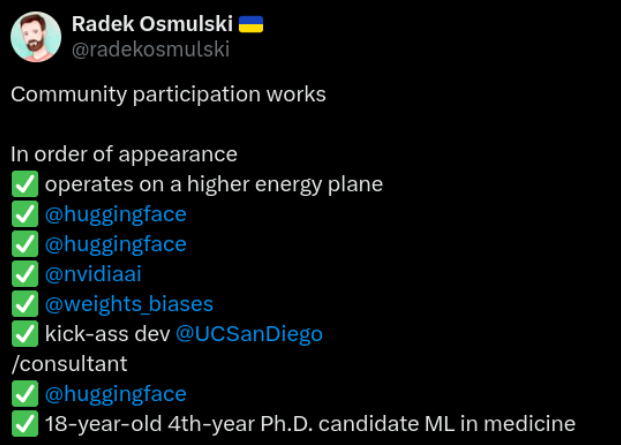

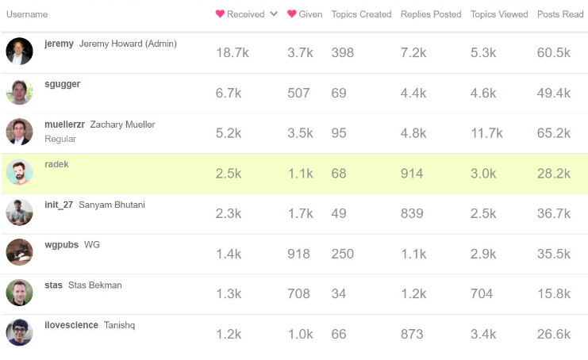

[figure not shown]

## How to become mini-Edison in your field of interest?

1. **Follow your curiosity**
   - I have no clue why this works, but it does. I keep seeing this over and over again.
   - Maybe we are naturally inclined to search for things that can be effective?
2. **Practice over theory.**
   - There exist two parallel worlds – a world where you are rewarded for being knowledgeable and a world where you are rewarded for making things that work.
   - It’s interesting to see GE Research attempting to leverage both.
3. Generally, there is no overlap.
   - People tend to maximize one or the other which produces really mind-twisting situations.
   - In 99.999% of technologies informed tinkering precedes theory.
   - So you have to choose which world to make your home.
   - Or maybe the decision is made by who you are and your personal history?

## Radek’s DL journey

1. **I would suspend my disbelief and do exactly what Jeremy Howard tells me to do in the fastai lectures.**
2. **Finish Fastai & follow the instructions precisely.**
3. **I will train a machine learning model after machine learning model.**
4. **Start your Kaggle Journey Sincerely.**
   - figure out how to move the data around and efficiently feed it to my deep learning model!
   - learn how to set up a remote VM for work and how to navigate around Linux.
5. **Become extremely active on Fastai forum & Discord , Kaggle Forum.**

## Persistency is everything

- Jeremy Howard was asked about what seperates the students that do really well for themselves from students who don’t. Without hesitation he answered - “**Perseverence**.”
- I am in my 8th year of this journey, I won a Kaggle competition and I am writing a book about machine learning. But most of the time I feel like a beginner. The code I write has bugs. I execute on the tactics I describe in this book imperfectly.
- But I continue to get better and better results. And, I don’t know a person who would be more surprised by this than me!
- I look around at the people I met along the way. They come from various backgrounds, had various starting points. My assumption is that if you were to know them better, or to know me better, you would be surprised by how ordinary we are. When it comes to me, ordinary is not even a good word. Fallible, misguided, caring about things that have no relevance in the longer run. All these would work better to describe me.
- And yet here we are, where you are reading the words that I wrote. Where I finally have a job I am very happy about in an industry well known for how well it pays.
- I can’t help to not agree with Jeremy Howard. He met way more people than I have and has a sharper mind. The only apparent distinguishing factor is how persistent one is.
- If you have a good map of the terrain, you can arrive at interesting outcomes much sooner than I have.
- Nonetheless, one thing is certain >> At any given moment, as you put in the work, you can barely notice a difference in your life. But the longer you stay the course, the more rewarding the journey becomes. Learning compounds and you need to give it time to start seeing the exponential results.
- Combine Persistence with community involvement and you cannot be stopped.

## How to gain a competitive edge over 95% of people learning ML

- **Machine learning is a vast ocean of ideas. That is why you need this very important skill to thrive in this sea of wonder :**
- At every point of your Machine Learning journey, you need to be crystal clear about what you are after. - Do you want to break into tech? - Do you want to become better at solving real-life problems? - Do you want to contribute to open source?
- **You can – and should – do many things over a year.** **But you should work on only a single project at a time.**
- Sun heats up and feeds the whole planet. A laser needs 1/100000th of the energy to cut through rock.
- **Are you doing the fastdotai course?** That means you are not: - taking MOOCs on [@coursera](https://x.com/coursera) - becoming a DALL-E prompt engineer - learning web dev from this one cool YT personality

**Want to win at kaggle ?** - Here are the things you are not doing then: - reading that fascinating book about doing statistics in APL - learning about programming paradigms on[@edXOnline](https://x.com/edXOnline) - There is no magic to success. - You do not need any special powers. - You pick one thing and you do it every day. - You look at your progress over X. - X ∈ {week, month, year, decade} - You ask yourself – is this what I need more of? - If YES: pass - else: do something else

- **You do not need to do a single thing in life only.**
- **But you need to only do a single thing at a time.**

## The Secret to learning ML Faster ⚡:

- **What is the ONE THING that is an obstacle to doing Machine Learning better?**
- Not understanding the theory behind some of the models? Not knowing the math?
- Be honest with yourself.
- Based on your experience, based on what you are seeing around you, is this REALLY what is in your way?
- **What is the shortest path FOR YOUR SPECIFIC CIRCUMSTANCES to massively improve at machine learning?**
- You have to be sensitive to your conditions.
- *For Example :* As I started to get really deep into Machine Learning ; I observed that the main thing stopping me from becoming much better at ML was my ability to read and write Python!
- The whole obsession with math and reading papers was just a mirage.
- The true area where I was hurting was my ability to read and write Python.
- Once I identified this the improvements were easy and results dramatic.
- So **what is the one thing that is in your way of becoming a better Machine Learning practitioner?**
- Is it your ability to configure your own workstation or set up a cloud VM?
- Is it your ability to structure an ML project and to grow it organically?
- What is it?
- Focus on that one thing. Don’t worry about what others do. You are the main protagonist in your own story!
- Don’t listen to what worked for people who are vastly different to who you are.
- React to your current setting.
- Eliminate the bottleneck to make the whole system of you as a machine learning practitioner running much more smoothly!

## Keep It Simple (KISS) 😇

- Give priority to really doing Machine learning / Deep learning , which will keep you motivated to learn all the secondary things around doing ML/DL , like setting up cloud VM , learning the Math needed, software design etc..
- This way you learn the things just needed to improve in DL ; Instead of spending months of research/learning those secondary things ; which results in Loss of Motivation and productivity and slow the progress.
- **“To start, focus on what things DO, not what they ARE”**

## Use Constraints to learn Machine Learning 12x faster! 🕐

- **Training the models and violating them properly** ie. robust evaluation and testing methodologies in assessing the reliability and generalizability of ML models beyond their initial training data.

> In ML, after training a model using a dataset, it’s crucial to evaluate its performance on unseen or test data to assess how well it generalizes to new, unseen examples. This evaluation involves various metrics and techniques to measure the model’s accuracy, precision, recall, F1-score, etc., depending on the problem type (classification, regression, etc.). deliberately testing the model’s limits by providing it with challenging or edge-case data points that might not align perfectly with the patterns seen in the training data. This process helps in understanding how the model behaves under different conditions and whether it can handle unexpected scenarios or outliers effectively.
- **Use constraints and Focus on whats important:**
  - Instead of dreaming of for the best DL hardwares , figuring out cloud VMs ; **See how far you can get in a kaggle competition just by using Kaggle notebooks.**
  - focus on **What are the quickest improvements possible to improve your models.**
  - **Use Constraints** : Set constraints on yourself ; to clean the space and focus on what matters.
  - **Don’t keep on researching for weeks:**
    - Timebox 2-4 hours or a day for thorough research; for what framework to use in this situation. And then Stop researching.
    - Jump into the framework , get good at it.
  - Find your fav ML expert; and Study the courses/books they used to learn ML.
    - **No course is perfect.**
    - **The value is in accumulating the concepts and knowledge and then moving forward.**

## The Most important component of any ML project

- **So what is the most important component of any ML project?**
- Is it the CPU, amount of RAM, disk space?
- Or maybe it is all about the GPU that you have? Or maybe the data?
- There is only one component that is shared across each and every project that you work on. **And that is - YOU!**
- The hardware, the data, all of it are just ingredients. And you are the chef.
- And therefore it makes absolute sense to devote the time and energy to grow your skills.
- In fact, **traversing the Kaggle forums, I am constantly reminded how much people can achieve with very little!**
- Instead of spending a month researching the tiny differences between various GPUs **Invest that time into actually training models AND developing your skills?**
- And if you are struggling with time management, you are not alone.
- [But you can always make your life simpler by deciding what you will NOT give your time, energy and attention to.](https://forums.fast.ai/t/what-i-will-focus-on-to-succeed-in-this-course/6926)
- Not only not getting distracted by Netflix, but also not getting distracted by another free course that we could passively consume.

## You have to get out of tutorial hell as soon as you can

You have to get out of tutorial hell as soon as you can. Its a complete waste of time. - How @fastdotai courses avoid this problem - What i am doing to not get stuck in tutorial hell when learning from other sources. - @fastdotai courses were designed using the top-down philosophy. - The Idea: - Share enough in a lecture to get one up and running. - Each lecture was a complete project – it provided all you needed to train an image classifier, recommeneder model, etc. - Also each lecture featured a call to action!

```
    - Walk through the notebook & figure out all pieces work together.
    - Train the model on a different dataset.
```

This is what i am doing to address this in my life that you can copy: 1. Reflect on how much time you wasted due to tutorial hell in the past. - Experience on its own is useless. - Only when you reflect on the experience and re-live the futility of an approach you tried in the past can you change your ways. 2. **Cut following a tutorial short.** - Most non-@fastdotai tutorials attempt to teach something complex. - But usually, you need very little to get going. - Stop early and work on something of your own. - Scan the rest of the tutorial to know where to look for info when needed. 3. Convert learning(going through a tutorial) to a standalone project. Examples of such projects: - @Kaggle competitions - a repository you create and tweet about - a blogpost explaing said thing

There are two crucial reasons why you should start working on a project of your own as soon as you can: 1. It is very motivating. 2. **You never know what you will need to learn up front.** - There are so many things one could learn on any subject! - Learning as you go – or just-in-time learning, is an incredible hack. - It tells you exactly what you need to learn. - Very often, you will be surprised at what you are missing! - You move fast not by hustling/dumping hours into doing stuff. - You move fast by honing your ability to focus on the essentials. - Two vastly different approaches.

## The Secret Power of Doing Things Badly

- **“Doing things badly” is a metaphor for overcoming perfectionism and fear of failure.** Instead of paralyzing oneself with the need to do everything perfectly, embracing imperfection allows for action, experimentation, and ultimately, progress.
- **Perfectionism is a roadblock to progress.** The fear of failure can prevent us from even starting, while striving for impossible ideals can lead to frustration and burnout.
- **Small, imperfect actions are often more powerful than grand plans never acted upon.** By taking tentative steps and accepting stumbles along the way, we pave the path for learning and growth.
- **A playful and positive attitude can unlock creativity and open doors to opportunities.** Approaching challenges with humor and curiosity can lead to unexpected solutions and breakthroughs.
- **Building connections and seeking support from others is crucial for navigating life’s challenges.**
- **Practice saying “yes” to new experiences, even if they feel outside your comfort zone.** What opportunities have you been avoiding out of fear? How can you step outside your comfort zone and embrace the unknown?

## The Secret to Learning Anything Well

- Learning has two phases:
  - ✅ first – you have to become comfortable doing something badly
  - ✅ only then – you improve
- Here is what happens when you skip the first phase.
  - Are you learning machine learning?
  - You might be feeling lost.
  - You might have a hard time figuring out what to work on.
  - You might think to yourself:
  - I will get better if I learn more math.
  - bzzzzzzzzzz
  - Wrong answer.
- Why?
  - Did you complete the first phase?
  - Did you learn to DO machine learning badly?
  - Do you feel comfortable moving data around?
  - Do you feel comfortable applying basic functionality from libraries such as @fastdotai or scikit to your data?
- Here is why this is important.
  - If you are learning ML and are not doing ML badly…
  - Chances are you are not doing any ML at all!
  - You are dying to perfectionism.
  - This leaves you flying blind.
- Here is what I mean.
  - You cannot learn to write poetry before you learn the alphabet.
  - No one can.
  - There is nothing wrong with you.
  - Machine learning is not harder than anything else.
  - You are just taking the wrong approach.
- What will happen if you learn to do machine learning badly first?
  - You will gain an understanding of the end-to-end process.
  - For every action that you will take you will receive feedback.

This is HUGE! ☝️

Machine learning will become very real to you. You will start building an intuition how to move around in it. More importantly - Now that you’ve made machine learning tangible. - You can let it guide you in your learning! - You no longer have to guess What to study! - Through feedback, you will know precisely What you need to improve. - This makes a world of a difference. - Its the difference between walking around blindly , and moving directly towards your destination. - You can learn to do anything well - But only if you first learn to be comfortable doing it badly.

## Learning is a product of quantity

- how many ML models you train ?
- how many blog posts you write ?
- how many issues you debug ?
- “**Produce indiscriminately, consume selectively**”

## Quantity leads to Quality

- It took me 8 years to learn this truth about learning ML.
- I’ll teach it to you in the next 5 minutes:
- I used to think
  - If I complete this one MOOC
  - If I write 8 blog posts in 8 weeks
  - If I do well in a @kaggle competition
- I will
  - have learned ML
  - my life will change in a substantial way
- That didn’t reflect reality.
- When your mental map does not align with the world
  - you experience stress
  - you are less effective than you could be
  - you lose the ability to direct your life

The proper mental map is this: - The only thing that matters is doing something over months or years. - If you believe - kaggle - blogging - doing MOOCs - something else - is your path, your only goal is to build it into your life. - To do it consistently over a long while. - Your short-term results do not matter. - Whether you feel you are learning or not doesn’t matter. - All that matters is consistency. - There are no exciting destinations you can get to in life in 24 hours Or a month Or a year. - Don’t write a single blog post. Write a hundred. - Don’t participate in a single @kaggle competition. Keep competing for the next two years. - Change your perspective to change your world.

## The Secret to Becoming a Data Scientist

- **Perseverance is Not Intensity**

> while **intensity** can offer quick progress and immediate results, it may sometimes hinder long-term retention, adaptability, and sustainable progress.

> **Perseverance**, on the other hand, promotes a more balanced and sustainable approach to learning, allowing for deeper understanding, adaptability, and long-term retention of knowledge and skills.
- **Perseverance is Not Discipline**
  - Avoid HARDWORK and DISCIPLINE to work like a labour.
  - Enjoyment should be the reason to work, not the results.
  - Find interesting ML Projects to build + Give Kaggle Competitions + Learn ML in community … etc
- Perseverence is **Finding something which I find exciting and thus keep on doing it for a long time (more than 2 decades)**
- Enjoyment is the key to Excellence (in every aspect of life).
- Why Perseverance works so well in learning ML ?
  - **Perseverance helps to build Strong Neural Connections of Knowledge.**
  - Entering into a new field (ML/DL/LLM…etc) ; You have to keep going , and find strategies that work. Embracing failures and try again try again.

## Journey of becoming employable in Deep Learning

- What I thought becoming employable in deep learning would be
  - learning a lot of math
- What it ended up being:
  - learning how to talk about your work
  - being able to point to the things you’ve done
  - learning how to learn
  - being open to new experiences
  - helping others
  - learning the craft of delivering good ML solutions to real-life scenarios (not covered by most textbooks/courses)
  - figuring out how to use social media and limiting the negative footprint
- **The Imposter syndrome**
  - when you think of yourself from 6 months, 12 months ago, can you see the progress you have made?
  - being able to monitor one’s progress is super important.
  - But it might not be best to compare oneself to others on social media. The environment favors hype and unsubstantiated claims and genuine progress and results take time. Many people chose the easier route because it works.
  - you will run into people that share with honesty, but they might have been doing something for many years now and it is not apparent. I know from my own experience that the speed I was able to move at in my 2nd year of studying machine learning was dramatically different from that in my 6th year, but looking outside in no one would probably be able to tell how much I have changed.
  - Sometimes the years of experience do not matter that much as I would suggest above - it’s more about what ideas and techniques you encounter at what point in time.

## Do tell the world - What you are upto !

1. if you do something, even with a modicum of success, make sure to tell the world about it!
2. **It DOESN’T MATTER how good your writing is!** Just type those characters out onto a screen and send them into the world.

## What to do once people know you through your work ?

- If you go deeper on something in a project, share something that might be useful to users of popular libraries, or put together a howto that can help a community… chances are you might appear as a blip on someone’s radar. Someone who might be an “industry insider”.
- if you are interesting enough, some of these people will reach out to you and introduce themselves in a DM! Or you might get to know them at a conference or a meet-up in real life.
- Well, if you are looking for a job, TELL OTHERS that you are looking for a job. This is the crucial ingredient, I cannot overemphasize it enough.
- If you’ve met this one person who took interest in your projects, and they seem like someone who is well connected in the industry, send them an email asking if they know of any openings that might be suitable to your skillset.
- If you are feeling particularly adventerous, put that info (that you are looking for a new role) in your Twitter display name. People use that all the time to advertise all sort of things
- Of course, don’t become a spammer. Only reach out personally to people whom you’ve built a connection with AND that plausibly can help you. As long as you are tactful and don’t hope for a response, you should be good.
- **Remember – don’t forget to tell the world what you want!**

## Magical Approach : “Value up front”

- **Deep truth –** Everyone in life and on the Internet thinking about themselves. So what is the absolute best way to stand out from the self-interested crowd? **- Do something completely selflessly for someone else!
- But If you are doing something seemingly nice and useful with the intetion to promote YOURSELF, or you expect gratitute, or to show off, you will be ignored (as you should).
- On the other hand, if you go about your life and think – “oh, this person is doing something interesting, is there something I could do to help?”
- Then, This is such an unusual event that it unlocks limitless opportunities!
- **How do you help other people ?
  - You look at what that person is doing and see if you can add genuine value.
  - Oh, they wrote a blog post? Maybe I can share my appreciation via retweeting it?
  - Oh, they seem to be maintating a software library? Maybe I can jump in and see if I can resolve an issue or two.
  - Do not introduce yourself.
  - Do not ask for the time of people you don’t know or where you are adding ZERO value to their undertaking.
  - **You just go around and be a good citizen AND DON’T EXPECT ANYTHING IN RETURN.**

## How to Think about - “ What To Work On ? “

- Let’s face it – **the only way to ensure we do something over a long period of time is to make it fun.
- if to become successful you need to do stuff you don’t want to (AKA force yourself to do stuff AKA the whole discipline thing) what is the point of changing your life in the first place?
- Isn’t the whole idea behind achieving success that you have more control over how you spend your time, that you can do more activities that are “fun” for you?
- Life is a journey not a destination and if you can’t make the journey fun, you are losing on the only game worth playing.
- **Enjoyment is the key to Excellence.**

## Small Bets

- Being aware of how much effort something will require is super important. For instance, let’s look at Kaggle.
- It is by far the best place to learn ML, to become one of the best in the world at ML.
- But incremental gains, going from being in the top 5% to top 0.1% requires a lot of work. Plus, what is very important – even if you are a Kaggle Grandmaster with 20 gold medals to your name, even if you understand how a problem should be approached, you still have to invest weeks of work to find yourself at the top of the LB.
- And that time can be very valuable.
- at every step of the way I plan to be aware of how much time and other resources whatever I end up doing will require and what results I’ll be getting!
- This is likely to not only help with how efficient I am with investing my resources, but should also help with how intentional I am about living my life!

## Being an Eternal Student

- If you are not making money through your side projects, then why go to all this effort at all?
- You can use the stuff that you create to build your personal brand. Nothing will showcase your skills better than a project you ship and write about.
- But **the true reason to work on side projects** goes deeper than that. And that **is that they are the best training grounds for acquiring new skills and honing the ones you already have!
- The learnings are the true currency of side projects and maximizing them is what I want to focus on!

## Strategic Mediocrity

- There are so many people around doing wonderful things.
- How do they do it? Are they fundamentally smarter/better than me? Are their actions THAT good to warrant attaining results I would consider a success?
- While that would be a very optimisitc view of the world (that people are good at what they do) nothing could be further from the truth!
- A perspective where you have to be good, you have to be great, to achieve success is paralyzing and a total MYTH
- The true world doesn’t work like that. You don’t get better by trying to be better. You get better through experiences. Through iteration. Through action.
- And the only way to get a lot of action under your belt is via accepting mediocricity.

> the main failure mode is not not being good enough, but not performing at all in the first place. - You’ll know when you’re doing great when you feel dumb most of the time but still interested in learning more.

## Focus on Creating Output

- For application-first people: every time you learn how and when to use a new algorithm, try to use it in a project. It’s okay if it feels forced or over-engineered. Your primary goal, for now, should be to build stuff and make them work. That’s it.
- You can also mix-and-match the algorithms to build even bigger projects. After I built an image-to-text extractor and a translator, the next thing I made was a knock-off version of Google Lens. It sucks, but it works! Once you get bored with that, try to invert the tasks. For example: instead of just detecting objects in an image, why don’t you generate images with your desired items in it - ala DeepFakes?
- For theory-first people: the books I recommended earlier are not novels, and the online courses are not movies. Try to implement the algorithms from scratch and prove every statemate or theorem you come across. If you think you can’t without reading ahead, then try to prove that too. No excuses.

## The True Alignment Problem

- How can I tell whether my side projects are bringing me the benefits I am after?
- How can you evaluate your own side projects?
- One way to approach this would be to list out the things you care about and see whether you are moving closer to them or not.
- But the review process needs to be ongoing. While working on something, or between projects, you have to be constantly monitoring whether you are on the right path or not and be ready to change your approach as needed.
- In fact, this point is broader than just ensuring you are on the right track.
- As you work on things you have not worked on before you will learn new things about the world. Maybe you will find that something is harder or easier to achieve than you originally assumed.
- Or maybe you will learn that doing things in public carries less risk than we generally think it does. For instance, in our connected world we often worry whether what we say here or there might impact our professional prospects.
- But the truth is that most people don’t care at all, they barely notice what we are doing.
- As we go along and collect all these learnings it is fundamental that we update our interal map of the world. And this, just as ensuring we are on the right track, can only happen through introspection.
- Through a continuous and deliberate process of reflecting on our experience (be that via discussing it with others, or writing about it).

## One last theme to bring it all together

- **Produce indiscriminately, consume selectively
- There is so much noise on social media. Everyone is so loud and the messages are so flashy. The best this, the legendary that.
- Plus it all is oh so interesting!
- And yes, there are many extremely valuable thoughts floating around. But it is next to impossible to get at them while sifting through piles of content where each piece is meant to trigger our emotions.
- That is why you have to be selective when it comes to the information you consume.
- **Books, Courses, Research papers, Tutorials, Documentation, Blogs, Forum discussions, Writing down and sharing my thoughts, ML Experts podcasts** are much better investment of time as compared to watching AI news , entertainment etc.
- If you are mostly a consumer you are missing out on creating a lot of value for yourself.

# Sairam

## How would I learn machine learning today

One of the most frequent questions I get is *“How would you learn machine learning if you were starting today?”.* I thought that it might be worth it to actually write it out and share it with all of you. Here’re 5 things I’d do if I were starting over today…

#### Tip #1: Get Going

If you’re unsure where to start and feel intimidated by the math, take a [code-first course](https://course.fast.ai/). If you feel excited by theory, take a [theory first course](https://www.deeplearning.ai/courses/deep-learning-specialization/). The most important thing is that **you start**.

#### Tip #2: Build your Fundamentals

Don’t worry about which framework to learn. Pick whichever one you like and run with it. What’s really important is that you learn the fundamentals. Pytorch, Tensorflow, and Jax are all frameworks that help you solve problems, but the fundamentals that they implement are the same. Focus on those first. Every time.

> **Frameworks come and go, fundamentals come and grow.**

#### Tip #3: Read and Implement Papers

Forget trying to keep up with all the advances in the field. Machine learning moves way too fast. Instead, understand the implementations of papers you’re reading and reimplement them yourself. That will help you tremendously and compound your learning.

> **The best papers of today will become the textbooks of tomorrow.**

#### Tip #4: Learn Publicly

Write about what you learn and share it publicly. You don’t need to be an expert. There are a million others who have the same questions you do. Make their lives easier. Share your knowledge. This is the step that everyone skips. Learning in public will build connections that you previously may have missed.

#### Tip #5: Be a T-shaped learner

Dive Deep into your area of interest like Computer Vision but explore other areas like Natural Language Processing, Recommenders, and Graph learning.

> *Great research ideas are the byproduct of cross pollination.*

### 5 Steps to 10x your Machine Learning Productivity

#### Step 1 : Rule of Three

- Ask 10 people how they’d handle multiple projects & deadlines and 9 of them will tell you to multitask.- This is not the solution.
- Instead, each day, write down the top 3 things you want to get done. These could be things that are time-sensitive or maybe are difficult problems you need to solve. Our brains aren’t great for storing information. They are great at thinking and problem solving.
- Multi-tasking forces the brain to juggle and remember tasks and where they are in the execution cycle.
- Writing 3 things down unburdens your brain and allows it to focus on what it’s great at — problem solving. Additionally, you get the nice dopamine hit when you finish and check off an item from your list. Any item that isn’t fully completed at the end of the day gets rolled over to the next day’s list.
- If you do this, here are the results you can expect to happen:
  - **Deep Work:** Uninterrupted spells of flow state allowing you to do your best work on a task.
  - **Less context switching:** No more switching between tasks when you’re in the zone. Additionally, no more background threads about the other task(s) you left unfinished while you’re working on the one at hand.
  - **No procrasti-planning:** Procrasti-planning is the constant mental gymnastics your brain does to organize the order in which things need to be done. Eventually, nothing gets done because you spent all your time and energy on planning and not on doing. Simply put, it’s procrastination masquerading as planning.

#### Step 2: Bitter Pilling

- Once you’ve got your 3 things, here’s the next problem you’ll likely face. We all have tasks on our plates that are boring, monotonous or painful to finish. For me, these are data annotation, cleaning, writing automation scripts and reports. Your instinct might be to finish off the tasks you enjoy first and then come to these painful blisters last.
- Don’t put the most boring thing off for last.
- Get it done first. Swallow the bitter pill. Why? If you do it first, you can enjoy the rest of the tasks in peace. Furthermore, you’ll be happy to get this work done soon so that you can devote your time to intellectually stimulating work. Another pitfall you’ll avoid is that you won’t repeatedly postpone doing them until your plate is filled ONLY with these kinds of tasks.

#### Step 3: Batching a.k.a Pipelining

- After you’ve accomplished Steps 1 and 2, now it’s time to pipeline. If you work with deep learning models, you’ll be familiar with the amount of time it takes to train and fine-tune them. What I’ve found is that these long windows of waiting are ripe for pipelining.
- While you have experiments that you are waiting on, do something else in parallel.
- For example, I read papers, answer emails or go get my workout done while my model trains.
- Models aren’t the only ones that work well with batches. You do too.

#### Step 4: Owl or Lark?

- At this point, you’re now ready to tackle peaks & troughs. Each of us have unique windows in a day when we are at our maximum effectiveness (peaks) and minimum effectiveness (troughs). The trick is to schedule our work so that we prioritize high impact work in these optimal windows.

**Here’s what to do:**

- Do your high impact work like coding, brainstorming, researching when you are at your peak effectiveness
- Do low impact work like automation, answering emails, logging bug fixes, etc. outside of peak hours
- Owls are those who are most effective at night. They thrive when their high impact work is done in the night. Larks are those who are most effective during the day. The converse is true for them.
- Are you an Owl or a Lark? Find out and maximize your effectiveness. *Do your best work at your peak hours*

#### Step 5: Build a bridge

That’s it! Now it’s time to build a bridge for the next day. A simple mistake I used to make was to just drop what I was doing at the end of a day and come back the next day to resume. A side-effect of this was that it took me a good half hour to identify what I was doing the previous day and what I had to do next.

- Find a good stopping point for unfinished work: Make it easy to pick up the next day
- Write a note to yourself on what you need to look at next. That way, you don’t start the next day with a blank slate
- Celebrate your accomplishments before you close

Overall, The reason this framework works so well is because it’s repeatable and your work compounds with less friction and mental burden. So, don’t fall into the trap of being a multi-tasking juggler.

Do this instead.

### One of the Best Ways to Improve Your ML Skills :

Let me tell you a secret:

> The single most effective habit that helped accelerate my learning wasn’t just reading papers, books, or watching lectures.
- It was actively studying others’ code.
- I ran code reviews of other repositories. This allowed me to learn how various algorithms were implemented and pick up best practices to use in my own work. This is how I did it (and so can you!):

#### Step 1: Implement the Algorithm Yourself

- Before jumping in to see how someone else has implemented a model or an algorithm, do it yourself first. It doesn’t need to be perfect. Just write out how you think the algorithm works and test it.

**Average case: It works. Best Case: It fails.**

- Why is that the best case? You will be more open to learning from another repository. If you’re anything like I was, the moment something worked, I’d immediately close my mind to exploring how it could be done better. It wasn’t until much later that I changed my perspective on how writing good code is an endless process.
- Step 2: Find Good (and Bad) Examples of the Algorithm
- There are a million repositories on GitHub that implement the same thing. How do you find out which ones to learn from? There are 3 simple options I choose from:

**Option 1: Use the Official Implementation**

- In machine learning, often times the algorithm you implement comes from a paper. That naturally means that there is a high chance that the code for the paper was released along with it.
- Start there.
- You can learn how the authors implemented various parts of the algorithm straight from the source.

**Option 2: Look up the Algorithm on Papers With Code**

- If you can’t find an “official” implementation, the next best bet (and in fact, this should be option 1) is to look at [Papers With Code](https://paperswithcode.com/).
- This site has a huge collection of papers with various repositories that implement them. In addition to the paper, you can see the top-ranked repositories that implement the paper.

**Option 3: Use the Number of Stars as a Guide**

- If the authors didn’t release the code (boo!), and you can’t find it on Papers with Code, then the next best bet is to search with the phrase “INSERT NAME OF ALGORITHM HERE GitHub”. Then, use the number of stars the repository has as a guide to choose a starting point. Usually, a repository with a higher number of stars ( > 1000) is a safe option to learn from.
- This isn’t a hard and fast rule though.
- There are many hidden gems out there that just haven’t gotten the eyeballs on them yet.

#### Step 3: Learn from the Contrast

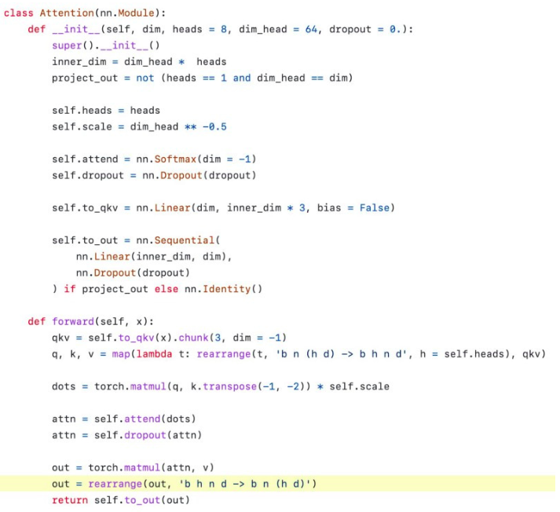

**Not All Repositories are Created Equal**

- Repeat after me. **“It’s ok to study poor code**”. 🧐
- While this might surprise you, look at what a legendary author says about the same thing in another domain:

> “**Every book you pick up has its own lesson or lessons, and quite often the bad books have more to teach than the good ones**.” ~ Stephen King
- You can learn a lot from poorly written code. It tells you exactly what not to do, why not to do it, and how not to do it. Bad code helps you clearly identify the pitfalls to avoid and how you can save hours if not days by writing good code in the first place.

#### Step 4: Expand Your Toolbox

You’ve now done all the hard work of studying and analyzing a set of good and bad implementations. But your job isn’t done. The last step of the process is perhaps the most important.

Reflect on your notes and your learning. Augment your toolbox. In particular:

- What are the techniques I can use going forward?
- How can I make my implementation more readable and clear?
- What are the things I should avoid when implementing this?

The next time you implement something, try to incorporate some of these learnings and see how they work in action.

#### Just-In-Time learning

- Learn something new exactly *when you need it* and bring together the resources you need *as you are learning*. This might seem a bit confusing. You could argue that you don’t do machine learning at work, that the topic you want to learn isn’t related to the research you do, or that you’re looking to learn machine learning to switch careers. What then?
- This technique still works. How?
- Just-In-Time learning is project-based. The project doesn’t need to be what you are doing at work (If it is, then that’s awesome). It just needs to be something you want to do.
- Simply define a project you want to pursue, say an image stylizer or a speech synthesis system, and work back from the goal. Find papers that solve this problem and read them. Augment your understanding through repositories in GitHub that solve the problem or a sub-problem. Work back from the goal until you have every single step mapped out.
- The key is to only collect and use resources that are directly relevant to your end goal. Ignore everything else.
- This ensures that you don’t waste time searching and getting buried under a never-ending pile of resources. So, we have a starting point. How do we deal with the lack of time?

For this, I take a leaf out of James Clear’s book [Atomic habits](https://jamesclear.com/atomic-habits). There are 4 laws of habit formation:

1. Make it obvious
2. Make it attractive
3. Make it easy
4. Make it satisfying

Applying each to Just-In-Time learning, we get:

#### Make it obvious:

You only collect resources that help with the end goal, so there’s nothing unclear as to what you should ignore. Every step you need in this learning journey is obvious.

#### Make it attractive:

If the goal of your project is work-related, then the rewards are explicitly laid out. If on the other hand, you are looking to transition into a career in machine learning, the #1 thing that companies look for is proof of work. There’s NO bigger proof of work than a body of GitHub projects, open-source contributions, etc. Courses and transcripts only go so far. At the end of the day, companies want to know you can actually do the work hands-on.

#### Make it easy:

Work on it, piece by piece, regularly. Even if you only have 30 minutes a day to devote to this, that’s fine. Show up. Your learning compounds over time. By committing to a manageable chunk of time every day, you make it easy for yourself and remove the “lack of time” excuse from your quiver of reasons to not learn.

Do the math: 30 days x 30 minutes per day = **900 minutes of focused learning

#### Make it satisfying:

There’s an intrinsic satisfaction you get by just showing up. When you master a hard skill, you gain confidence, and each new thing you learn helps you learn harder things more easily. Learning is its own reward.

# TryBackprop (MLE @FAANG)

## Hows the market saturation of AI/ML engineers these days and how to overcome it ?

- At FAANG, there isn’t too much saturation. In fact, for the most part, the AI/ML engineer role was resilient to the tech layoffs and the hiring freezes of the past two years (of course, there are exceptions if you’re underperforming). What I found interesting was even during “hiring freezes”, FAANG made an exception for senior level ML engineers.
- The market is likely saturated with underskilled AI/ML engineers, so to overcome it, after you get some ML experience, to set yourself apart from the others, get familiar with the fundamentals. It’s not enough to know how to use the ML libraries like PyTorch/TensorFlow. You must also understand why they work so that you encounter production issues with real world systems, you can debug them more easily. It’s not a good use of time nor is it feasible to read through all real world systems code so you need to sharpen your ML reasoning skills. To help, Andrej Karpathy’s zero to hero series on YouTube is incredibly valuable: https://youtu.be/VMj-3S1tku0?si=SI7f8BnJDmQleBkf. For context, Karpathy graduated from Stanford with a ML PhD, and he worked at OpenAI and Tesla as an AI director on their self driving car effort.
- As for engineers with zero experience in ML, it helps to land a role in an ML team where you’re working on regular software engineering. At least you’re close to the ML action. I’ve seen many engineers take that approach. Then, at home, continue to learn ML at home when you have time. Eventually, once you’ve built up enough context at work, you can ask your manager for a role change within the team or at least start working directly on ML projects. I know this works because my coworkers did this, and I’ve done this as well.

## Since AI field is developing so fast how do u stay up-to-date?

- The AI field is developing fast, but the major breakthrough concepts come out every few years, so you can spend most of your time on the breakthrough concepts and not feel like you’re drowning in every new paper that’s coming out.
- For example, you should spend way more time on the “Attention Is All You Need” paper by Google that introduced the Transformer than you should on the latest paper that just came out yesterday. Plus, once you study the major breakthroughs and know them well, you start to notice that the other ideas are just derivatives of the breakthroughs and require just one or two tweaks of the breakthrough idea.
- For example, I spent about 3 months trying to understand all the nuances of transformers. Then, I spent about 2 weeks building one from scratch and training it on a tiny dataset and getting it working. After that, reading the papers on GPT-1, GPT-2, and GPT-3 were relatively easy (less than 1 hour each). At that point, learning about Llama 1, 2, and 3 became a very quick scan of the paper and noticing what changes they made to the transformer and noting which changes were worth diving deeper into. This knowledge builds on itself and compounds so once you study the breakthrough ideas, the rest come relatively easy. Furthermore, you build up more confidence in yourself that you’re absorbing new concepts faster and faster.
- Also, I talked to my friend who’s a researcher at Deepmind and my other friend who’s a researcher at OpenAI, and they both independently told me that most of the papers that come out are bogus, and you just need to talk to the experts to know which ones to pay attention to. If you don’t have access to the experts, simply look at a paper’s number of citations, and if it’s in the thousands, it’s a good signal that it’s an important paper.
- You’ll also know a paper’s worth if there are plenty of implementations of it on Github. Of course, some papers have no open implementation, which doesn’t mean it’s a worthless paper. One time one of my coworkers showed me an efficient and fast way to implement e^x so that our Android code would run faster and wouldn’t use as much power (and thus save battery power for the user). I looked up the paper that originated the fast implementation and it had very few citations, yet it was a very useful and powerful technique!

#### Would familiarizing oneself with Data Engineering concepts be helpful?

- Yes I’ve found data engineering skills to be very valuable so early on i decided to pick up those skills so that i would not be blocked on data engineering work for my projects. The skills made me immensely more efficient at work.
- Recommended Resources :
  - Data Engineering zoomcamp (great course)
  - Designing Data intensive applications Book
  - Designing Machine Learning Systems - Chipro Book

#### Are jobs more geared towards mlops now, are ML engineer/jobs still focused on dsa/ml/ design ?

- Definitely! The ML engineers I work with focus on DSA, ML, and system design. In fact, that’s most of what we do. I also I have teammates that run the ML ops part of the system, but day to day, my coworkers and I are designing new models, implementing papers/faster algorithms to reduce compute and memory usage (which is very constrained these days due to the chip shortages) and designing new monitoring and measurement frameworks that require knowledge of probability, stats, and basic linear algebra.

#### Is maths helpful ? ML maths looks daunting to learn ?

- To answer your question, yes the math foundation definitely pays off later on. However, if you lose motivation to continue because you feel it’s a slog, you can skip straight to the ML coding and whenever you get stuck on a math concepts, simply learn it then. That way you won’t feel like you’re learning math with no sight of the end of the tunnel.

#### What do you see at FAANG for folks who want to pursue say DL compilers, GPU programming, distributed training etc etc? (Just picked a few but I hope you get the gist).

- I know a couple engineers who hopped around from general ML to GPU programming, distributed training etc. They took it upon themselves to learn CUDA programming, organize tech talks with experts from Nvidia, and proactively took on challenging GPU programming/distributed training problems that very few in the company could solve. They also found opportunities in other teams and switched when they wanted to take on different responsibilities. As a result, they were rewarded handsomely by the company since their passion in these areas resulted in massive savings for the company as well as more cutting edge research and product development.
- For GPU programming, FAANG experts recommend reading Paulius Micikevicius’s Nvidia blog: https://developer.nvidia.com/blog/author/paulius-micikevicius/. Google “Paulius Micikevicius GTC” if you want to learn more. Furthermore, I recommend listening to the PyTorch developer podcast: https://pytorch-dev-podcast.simplecast.com/episodes/all-about-nvidia-gpus.
- If you want to dive deeper into ML systems engineering, these resources are very helpful: Chip War – NYTimes best selling book by Chris Miller Asianometry – YouTube channel with 667k subscribers by Jon Y SemiAnalysis – tech journal with 95k+ subscribers by Dylan Patel
- [Author: Paulius Micikevicius | NVIDIA Technical Blog](https://developer.nvidia.com/blog/author/pauliusm/)
- https://pytorch-dev-podcast.simplecast.com/episodes/all-about-nvidia-gpus

#### Any tips for becoming a “ML Infrastructure engineer”?

- Becoming an ML Infra engineer is relatively simpler jump actually. I would highly recommend reading this book if you want an accurate picture of what its like being an ML infra engineer. **“Designing ML Systems Production Ready”**!.

#### How to learn the most relevant DL fundamentals ? is Leetcode imp ?

- Yes, I think Andrej’s videos give you a good grasp of modern ML technology. You can then add on from there.
- I would prioritize leetcode when you’re 2-3 months away from interviewing to give yourself ample amounts of time to study 1 or 2 problems a day or so. Shorten the amount of study time if you don’t mind cramming.

### Grind Leetcode or ML ?

**Do as little Leetcode as you can get away with,** **But Read as many ML papers as you realistically can.**

- Do as little leetcode as possible (1.5-2 hrs everyday)
  - Once you are able to solve medium level LC problems, >> Pay less attention to LC
- Read ML Papers consistently
  - The goal here is - Consistency over quantity
  - At start ; Commit to - Reading 1 ML paper per week.
  - Gradually make it **2 papers a week >> 100 papers per year**

#### How to Prepare for ML interviews ?

- [Free ML Resources to Become a FAANG ML Engineer](https://www.trybackprop.com/blog/top_ml_learning_resources)
- DSA: prepare with https://neetcode.io/practice. Do the neetcode 150
- ML : go through this curriculum by a former OpenAI researcher , https://github.com/jacobhilton/deep_learning_curriculum
- [FAANG Interview – System Design](https://www.trybackprop.com/blog/system_design_interview)
- [FAANG Interview – Machine Learning System Design](https://www.trybackprop.com/blog/ml_system_design_interview)

# Vicki Boykis

[How I learn machine learning | ★❤✰ Vicki Boykis ★❤✰](https://vickiboykis.com/2022/11/10/how-i-learn-machine-learning/)

**All you have to know as an MLE is :** - computer science fundamentals: data structures, algorithms, object-oriented programming - an in-depth understanding of production engineering best practices: monitoring, alerting, unit testing, version control, latency, throughput, scale - fundamentals of machine learning and statistics: traditional models, sampling, A/B testing - an informed opinion about all the currently popular trends in a machine learning stack so you can select from them - an understanding of the developments in the field you specialize in (medical AI, recommendations, search, ML for security, each of which are formulated as different problems and have their own context and vocabulary) - YAML

**Learn the basics** - There are lots of concepts to learn in ML engineering. But the concepts are not distinctly unique. - When I started thinking of learning as a process that involves going extremely wide on core fundamentals, then going deep and building links across fundamentals, it made it the process a LOT more manageable. - Example 1 : once you learn **OOP** in Python, you’re going to have much easier time understanding Fastai library. - Example 2 : **graph data structure** - A graph, like all data structures, has special properties: it’s not linear, it has nodes, the numbers, and edges, which connect the numbers. - First we go broad: In order to understand a graph, we have to understand what the alternatives to it could be: It’s different from other data structure, like arrays, lists, and hashmaps. So now we’re covering algorithms. - once we understand graphs as a data structure, we understand that [trees are a form of graph.](https://stackoverflow.com/questions/7423401/whats-the-difference-between-the-data-structure-tree-and-graph) - And once we understand trees, we understand that DAGs, one of the canonical data structures in data data work, are a type of tree, as well, and can also be traversed. - This gets us now from abstract data structures to things that we work with every single day: [Airflow DAGs](https://airflow.apache.org/docs/apache-airflow/1.10.12/concepts.html), [execution plans in Spark](https://stackoverflow.com/questions/7423401/whats-the-difference-between-the-data-structure-tree-and-graph), and Tensorflow/PyTorch [computational graphs.](https://pytorch.org/tutorials/beginner/blitz/autograd_tutorial.html) - Also , we can grasp Graph neural Networks , a little fast.

- Example 3 : **Numpy Arrays**
  - once you understand Numpy arrays, you understand how they build to Pandas DataFrames and PyTorch tensors.
  - So just by learning one foundational concept, we unlock being able to work with it across various domains within machine learning and relating concepts to each other. We can also now reason about what data structure might work best where and what kinds of engineering tradeoffs we make when implementing X or Y.
  - The more foundational concepts you learn, the more you put into your working memory to synthesize with what you already have available and the easier it becomes to create connections
  - As a quick primer, the human brain has several types of memory, short-term, working, and long-term. Short-term memory gathers information temporarily and processes it quickly, like RAM. Long-term memory are things you’ve learned previously and tucked away, like database storage. Working memory takes the information from short-term memory and long-term memory and combines them to synthesize, or process the information and come up with a solution.
- **everything you read in machine learning and engineering repeats.**
  - So, if you don’t understand the first time, don’t feel bad. Just pick up a different book (or three). You will already have the foundations of the first book to guide you.

# Umar Jamil

### How Umar Jamil learnt MLE

- **Read as many papers as possible** (since AI is evolving so fast, no book will teach you everything u need to know)
- **Always Be Coding** (ABC) :
- **Solve Problems:**

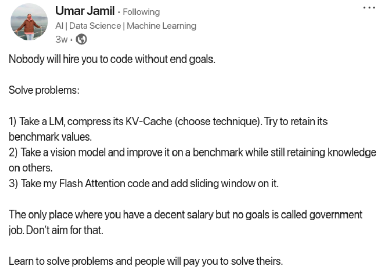

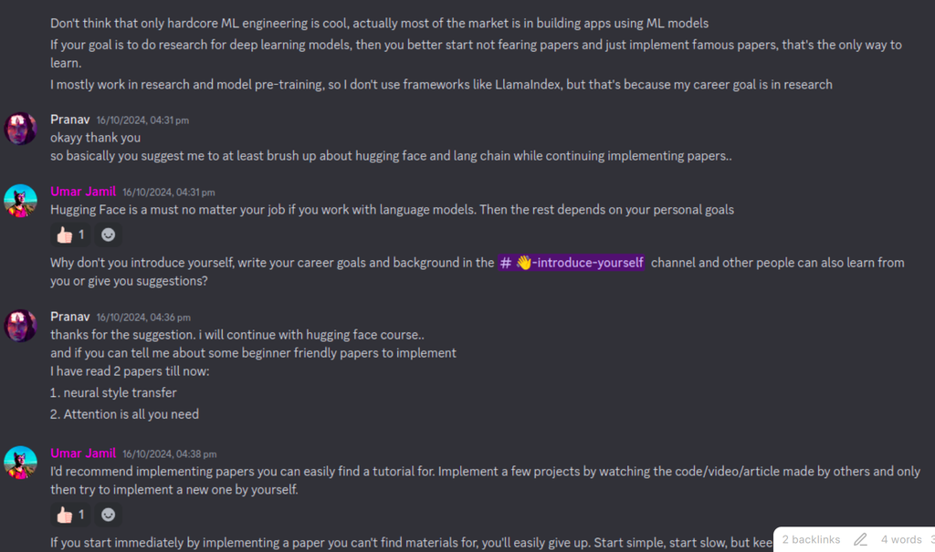

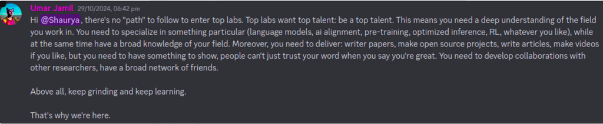

#### Lessons learned as a Research Scientist

- Follow a T-shaped learning (as Andrew Ng told in his Career in ML lecture)
- Have some fundamental knowledge in CV, NLP, DL, classical ML, GPU programming..etc
- And Build Expertise in one of them.

### How Andrej taught himself ML engineering

- **Always start coding with an end goal.**
- Coding Llama from scratch - is great to learn LLM fundamentals.
- But nobody will ever pay you to code llama from scratch you know what they will pay you for is take llama and try to quantize it in such a way that it retains as much as per the performance as possible
- So always build things whatever it is at an API level at the machine learning level with an end goal
- **for example:** imagine you are creating a company for a machine learning model inference who do you need the guy who on hugging phase just on a weekend delivered a quantized version of a model that you want to put on your service or the guy who can code llama and never quantize the model and never influenced the model ever in his life so building means do something with an end goal
- think always in this terms of business like I am going to launch a business that is doing machine learning inference or trying to solve a problem What problems will I have I will have probably the problem of okay how can we Host this model and make it as fast as possible or there is a new model and this context length is only 8K can we take it to 16k so let me do it.
- I know they follow tutorials and they make projects yes but you are just copying some code that is online did you actually deliver something because if I am the founder of a startup I can do that myself I need people who solve problems for me
- So learn to solve problems
- Take any model and you start beating a benchmark
- You take a model and you say okay this model is not really performing on a medical data so let me take a data set on medical data and try to improve the performance of this model on medical data trying to retain as much knowledge as possible
- The Learning Journey that will take you to beat The Benchmark will be enough for you to enter this field
- that’s what karpathy did. He wanted to learn about training of language models so he started writing a little script in Python to train a language model then he was pissed off because he said I don’t really understand what is happening under the hood then he started coding it in C and it called the he called his repository llm.c
- then he realized hey I can train this stuff I can understand this stuff and people start contributing to it and then he realized hey there are these things called cuda kernels I can write these Cuda kernels and they make it go fast then he realized hey I can go very deep into kernels so just by teaching himself something which is I want to train a model and this is the problem I want to solve and I want to do it the fastest way possible he teach him self all the field actually he teach himself all the things that he needed to master this field.

### Umar’s journey : learning CUDA, triton & Flash Attention

- **What is CUDA, Triton, Flash Attention ?**
  - **Flash Attention** is an optimised implementation of attention mechanism used in Transformers to make better use of GPU compute power. In the paper it’s refer to an “I/O-Aware” algorithm.
  - **CUDA** is a software stack from NVIDIA to write GPU kernels for NVIDIA GPUs. Other GPU manufacturers have their own software stack (the equivalent for AMD GPUs is ROCm)
  - Triton is a software stack that compiles GPU kernels written in Python into native code for the underlying GPU hardware (CUDA, ROCm, both compatible as of now.)
- **I want to learn Triton : How do I start ?**
  - Before you start learning anything , ask yourself : “Why do I want to study triton ?”
    - In Umar’s case : he like experimenting with new architectures and with new architectures you may need new kernels for accelerating the training process. Too many times I was blocked because i didn’t know how to edit/debug the [[Kernel]]s.
  - Now its time to go to > [Triton’s website](https://triton-lang.org/main/programming-guide/chapter-1/introduction.html)
  - Oh! I am confused what’s this ?
- **You can never get lost: What’s this ?**
  - Anytime you are blocked somewhere and you don’t understand something - you can always prompt
  - And you can never be blocked - because you can keep prompting untill you’re unlocked ! They will put you in right direction.
  - Prompt >> [[What is Triton and How can i learn it ?]]
- **Get your hands dirty !!**
  - You learn more by doing things and not just studying it (conceptually).
  - Look at Triton Tutorials.
- **Set yourself a goal/dream**
  - Umar saw [Fused Attention](https://triton-lang.org/main/getting-started/tutorials/06-fused-attention.html#sphx-glr-getting-started-tutorials-06-fused-attention-py) coded in 400 lines of python code - and made a goal to understand it + re-implement it himself (in his Triton learning journey).
    - Prompt >> [[How is Flash attention and fused attention related ?]]
  - **Always “Have a goal when you learn things”**
  - Don’t just learn Triton.
  - Learn Triton in order to understand the Fused Attention.
- **Why having an objective is important when learning ?**
  - You always have something to measure against.
  - You never get lost.
  - It gives you sense of satisfaction when you reach your goal.
  - Intermediate Goals also helps alot.
- **Learning Strategy:** Avoid being influenced by others’ tutorials initially. Challenge yourself. Define the “rules” of your learning challenge
  - What are the rules of this objective ?
  - Am I allowed to read papers, watch tutorials, blogs, code ?
  - The difficulty of the challenge you choose - you’ll improve confidence+competence accordingly..
- **Practical Steps:** Started with the “vector addition” tutorial on the Triton website.
  - Now we are trying to do the vector addition tutorial and we found an obstacle (Encountered concepts like pointers, block size, and thread IDs.) and we found resources about on how to kind of overcome this obstacle
  - **Overcoming Obstacles:** When blocked, use the debugger or prompt LLMs to identify missing knowledge.
  - **Targeted Learning:**
    - You are doing triton , to understand flash attention
    - You are doing vector addition (implemented in Triton’s first tutorial, on triton website)
  - **Learn just what you need , no more, no less**
  - When seeking external resources (like the “Programming Massively Parallel Processors” book), learn only what’s relevant to the immediate task (just learn enough for us to understand the things that are relevant to the vector addition only)
  - I went to pmpp I I learned the first two chapters I think enough for you to understand vector addition and to give you a little intuition on all the concept that you need to at least understand fully.
- **Final Boss:** Finish the tutorials, then move on to the “final boss” - flash attention.
  - When we start reading (Flash Attention) paper, we encounter so many new terms… So let’s go down rabbit holes ?
  - Untill now - our strategy was - every time we encounter an obstacle - we ask chatgpt for directions ; overcome the obstacle and go back to objective.
  - **Paper Reading strategy is different**.
    - **Learn to handle the uncertainity.**
      - Read the entire paper , top to bottom , even if you understand 5% of it.
      - While reading the paper , you’re constantly reminded of how many things you don’t understand and this makes you uncomfortable: its fine. Keep Going On!
      - Once you reach the end , you’ll have a clear vision of what you don’t know, and now you can come up with a plan for how to fill your knowledge gaps.
      - Tip: **Highlight with different colors** >> [[Color coding research papers]]
        - things you don’t understand at all and you’d like to learn
        - things you don’t understand and you’re fine not understanding (because maybe are not so relevant for your journey)
        - things that you already know & you’d like to improve your knowledge on, etc.
      - plus your brain is actually very smart at connecting dots even on things that you are not not fully familiar with.
      - **Don’t highlight while reading.. Highlight after reading.**
        - because this forces you to go through it again of course not every paper you can do it like this so it depends really on the level of depth that you want to reach
      - **Read the paper atleast 3 times – end to end.**
        - Now you know your objective - to understand all the necessary concepts/parts of this paper.
        - Now you can go into rabbit hole of learning each of those concepts & you always comeback to the paper.
- **Learning Roadmap:** Built a roadmap by identifying knowledge gaps in the Flash Attention paper (softmax, online softmax, GPU programming, backpropagation).
- **What ingredients do we need to understand FA ?**
  - Attention mechanism
    - Softmax
    - Safe Softmax
    - Online Softmax
  - GPU programming
    - HBM and Shared memory
    - Tiling
    - Tensor shapes
    - CUDA/Triton
  - Backpropagation
    - Gradients
- **First Boss :** Softmax
  - If you go to the[flash attention paper](https://arxiv.org/abs/2205.14135), the key challenge in implementing Flash Attention, particularly related to computing softmax when processing attention matrices in blocks.
  - The core issue with block-wise computation of attention is handling the softmax normalization factor correctly.
  - The problem arises because softmax requires knowledge of all values in a row to compute the normalization denominator (the sum of exponentials). When processing in blocks to save memory, you don’t have all values available at once.
- **The two weapons to fight softmax :**
  - [Self-Attention Does NOT need O(n^2 ) memory](https://arxiv.org/pdf/2112.05682v2)
  - [Online normalizer calculation for softmax](https://arxiv.org/abs/1805.02867)
- **Reading is not enough. You need *Active Learning.***
  - If there is an algorithm , code it.
  - if there is an algorithm , test it on paper.
  - if there is a proof :
    - re-write it yourself on paper , the first time.
    - if you want deeper understanding, try to redo the proof without having it infront of you.
- **but I still didn’t understand it… What should I do ?**
  - Imagine you studied the online softmax, coded the algorithm, did the proof by yourself, but you still can’t figure out how it may be connected to FA .. What should you do ? Should you keep studying “online softmax” or should you continue ?
  - After a reasonable time spent on a problem , **Continue Forward** and accept the uncertainity & the possibilty that you may have to go back to it again in future.
  - **Iterative Learning:** Go back and forth between different resources (e.g., the Flash Attention paper and the online softmax paper) to reinforce understanding.
    - what I do usually in these cases is go back and forth so I go to the flash attention paper try to understand how it’s used then if I don’t fully understand go back to the online softmax because every time you go back and forth
    - so when you go back to the online softmax from the flashh attention paper you are reinforcing your learning of the flashh attention by trying to make it work with whatever you’re learning from the online softmax.
  - **Combining Code and Theory**: Alternate between reading the paper and examining the code for new architectures.
    - When I read a new architecture paper ,i don’t fully understand it just by reading the paper. Hence i go back and forth between the code and the paper.
    - Sometimes The code is very cryptic as its written by researchers , not by good engineers, hence learn from paper and code together.
- **Block Matrix Multiplication:** Learned about block matrix multiplication, crucial for understanding Flash Attention’s block-by-block computation.
- **Tensor Shapes and Strides:** Understanding tensor shapes and strides is essential for GPU programming, as GPUs work with memory pointers.
- **Backpropagation:** The most challenging part, requiring understanding of gradients and chain rule.

### What should I learn next ?

- What should I study next in order to grow in my career ?
- **First rule :** Follow curiousity , not hype.
- **Second rule :** Focus on consistency. it doesn’t really matter how bad your start is, with enough consistency, with enough trial and error, you can fix any intial bias in your learning.
- **Third rule :** if your learning speed hasn’t accelerated by using LLMs , youre doing something wrong.

### How to keep up with research pace ?

- Everyday we see 100s of papers published. How to cut the noise ?
- **Accelerated Learning**:* Modern tools (LLMs) significantly accelerate learning. Prompting replaces time-consuming searches.
- **Dual Stream Learning**:* Keep up with new research (“noise stream”) but maintain a long-term learning focus.
- **Secret Ingredient, Confidence**:* The most crucial element is *you*. Build confidence by tackling challenging tasks. Push yourself beyond tutorials.
- **Building Confidence**:* Confidence comes from doing hard things, and pushing yourself further.
- **Leaderboard Participation**:* Encourages participating in the GPU Mode leaderboard, even if not fully confident. The only failure is not showing up.
- **10,000 Hours Rule:*** Is the only rule that matters in life.

# Rohan Rao

- **How do you manage time?**
  - Focus on Prioritization & Sacrifice and have the Discipline to Plan & Pursue. I believe it is a very underestimated skill.
- **How to choose the right ML model and parameters?**
  - Set up the right validation framework - [[Good Validation Set]]
  - Experiment on as many models, architectures, hyperparameters
  - Pick the one that best suits your needs (accuracy, stability or latency are usually the choices)
- **Is statistics a major pre-requisite for learning ML?**
  - Desire to learn new things. Perseverance to read, code and experiment hands-on. Willingness to invest time and energy.
  - I’d pick these as more impactful pre-requisites over statistics.
- **What helped you improve concepts in DS?**
  - In order of impact:
  1. Desire to learn
  2. Investment of time
  3. Google searches / YouTube videos
  4. Kaggle forums / notebooks
  5. Source codes / GitHub repos
  6. Research papers
  7. Friends
- **Research vs Implementation priority in ML?**
  - You need to nurture and grow your knowledge in both.
  - Without research, how do you know what to implement?
  - Without implementation, how do you know the impact of research?
  - They are two sides of the same coin.
- **Which is your favourite ML model?**
  - In this fast-moving ML field I don’t believe in marrying any algorithm or technology.
  - My favourite model is the one that gives me the best results!
  - Having static favourites can stunt growth. Let it change based on the data.

# Inspiring MLE Stories

## Soumith Chintala

### Never Give Up!

If you feel like giving up, you must read this never-before-shared story of the creator of PyTorch and ex-VP at Meta, Soumith Chintala.

- from hyderabad public school, but bad at math
- goes to a “tier 2” college in India, VIT in Vellore
- rejected from all 12 universities for US masters despite 1420 on the GRE
- fuckit.jpg
- goes to the US anyway on a J-1 visa to CMU with no plan
- applies for masters (again) to 15 universities
- rejected from all except USC and with late admissions, NYU in 2010
- finds this guy called Yann LeCun (before he was famous)
- starts getting into open source
- rejected from all jobs including DeepMind
- only job is Amazon as test engineer
- his PhD mentor helps him get a job at a small startup (MuseAmi)
- rejected from DeepMind
- couldn’t get H-1B because of J-1 home return issue; gets waiver through months of approval with USCIS and US State Dept
- very low on confidence
- In 2011/12 builds one of the fastest AI inference engines on phones
- rejected from DeepMind
- emailed Yann again and joins FAIR because of Torch7 open-source work
- scrapes through bootcamp at Facebook, struggling on an HBase task
- L8/L9 engineers at Facebook struggle to get ImageNet working
- figures out numerics / hyperparam issue as an L4
- first big win!
- FAIR goes well, runs 3 person torch7 team and co-creates PyTorch
- because of politics, management wants to shut down PyTorch
- cries-at-bar.jpg, literally
- eventually some people save PyTorch and it launches in 2017
- gets a EB-1 green card!
- the rest is history…

Think about that. He went to a tier 2 college. Was rejected from all Masters programs 2x. Rejected from every single job except Amazon test engineering. Rejected from DeepMind 3x. Nearly had his baby project shut down. Struggled with visa issues. After 12 years of failures (2005-17), he eventually rose to became a VP at Meta one of the most influential people in AI!

Soumith’s story is one of resilience and he’s living proof that no matter how down in the dumps you are, there’s always hope.

### Soumith’s Journey to Deep Learning

- Soumith went to study at NYU because he found out about Yann Lecun (after doing a google search). Ended up meeting Yann (simply by emailing him and asking! ).
- Soumith admitted to Yann that he knew nothing about neural networks so Yann offered help with one of his Phd students.
- When Soumith graduated from NYU he couldn’t find any jobs in DL since it wasn’t really a “thing” at the time and positions for DL engineers didn’t exist.
- Later he realized that Yann had co-founded a startup and was using neural networks so Soumith ended up initially working there.
- Eventually, Yann was recruited to head up the FB AI Research Lab and he invited Soumith to join him (once again).

**KEY TAKEAWAY:**

- Don’t be afraid to admit when you don’t know something (be honest with yourself and others - don’t pretend to know) and most importantly don’t be afraid to ask for help!
- All it took was Soumith taking that first step in emailing to Yann that kickstarted his whole career path and eventually creating Pytorch.
- Of course, this is not to say that he has most definitely earned everything that he has gained today and must have worked extremely hard to get to the level he is currently at.

### Soumith’s advice to start a career in Deep Learning ?

- You don’t need a 4 year education to learn about and become good at deep learning and neural networks (high school math level)
- You definitely don’t need a Phd. No-one on the Pytorch team had a Phd and they still turned out fine.
- However, doing a course is not enough, you have to apply what you learn. That means creating Github projects, writing blog posts, doing Kaggle competitions, reading & implementing research papers.
- Don’t just read papers or consume information, you have to put it in practice and also you have to keep your skills sharp. (Oh wait that sounds a lot like what we are doing here at Fastai)
- As a result of doing all this, you are sending signals to others that you have the skills they need. Other people won’t know what you know unless you show them.
- Whenever you don’t understand something, mapping it back to the domain you know and understanding it from first principles always helps.
- Even super-confident people sometimes do not know what they’re talking about. It just means they know a few things about something, certainly not in its entirety but most importantly they are quick to course-correct incase they see a mistake in their understanding.
- Get a lot of feedback. Why do you think the greatest of the athletes / teams have coaches? Because, it just works. Feedback is the most important experience in learning something. (We Machine Learning guys surely know the value of feedback)
- Ability and humility to ask.
- Have a growth mindset instead of a fixed mindset. (Growth is always dx everyday, however it always amounts to something really valuable over time)
- Getting a job is a marketing exercise. Write blogs, GitHub is your best friend, create your own portfolio. More importantly, be authentic.
- Be an excellent story teller. They recruiters are not trained to connect your dots. So, figure out your story and present it in the best way possible.
- Shorten the distance to your dream company: Figure out the engineering blogs, identify the team members on Twitter, talk to them about any interesting insights you found on their blogs, and establish meaningful conversations. Don’t blindly run behind recruiters.
- Evaluate the work and team you are dreaming of. Be critical.

# What is really ML engineering in the industry

- [The different types of MLEs](https://raymondyoo.com/blog/the-different-types-of-mles/)
- [Don’t waste time like I did in my ML career](https://raymondyoo.com/blog/dont-waste-time-like-i-did-in-my-ml-career/)
- Chip’s MLE interview book

# CONSISTENCY

### You’re Not Lazy, You Just Lack a Habit

If you’re struggling to stick with demanding forms of practice, then temporarily forget about efficiency and just build a habit with some less effective but more enjoyable form of practice. Although the ultimate goal is to train efficiently and get the largest possible performance gain out of your limited training time, that’s going to feel taxing, and you might not want to work that hard at first – not because you’re inherently lazy, but because you haven’t built a habit. You eventually want to get to the point where performance improvement is your primary focus and fun is a second-order optimization, but it’s okay to optimize for fun at the beginning to help you build a habit.

Consider strength training, for example. If you’re just starting out, but you’re not looking forward to lifting heavy-ass weights, then that’s okay! You don’t have to lift them yet. Your #1 focus should be just getting your ass into the gym and doing some kind of activity that loosely qualifies as exercise. After a week of, say, shooting hoops, you might be motivated to try some bodyweight exercises – and then the following week maybe some light weightlifting, and maybe the week after that you’ll be ready to challenge yourself by putting some serious weight on the bar.

It’s the same way with anything else – for instance, learning Deep Learning. If you don’t feel motivated to solve a high volume of problems that are challenging enough to make you mentally sweat, that’s okay. You can start off watching Deep Learning edutainment videos and exploring Wikipedia. The next week, maybe try to solve some “Deep Learning meme” problems each day (and look at the comments to check if you got it right), and the following week, maybe work out some easy arithmetic or algebra problems each day (stuff that you still remember fairly well but haven’t done in a while). By that point you’ve gotten yourself into the metaphorical weight room, you’ve done some light lifting, and you’re ready to put some serious weight on the bar. And that’s when you start working through a structured curriculum that engages you in taxing practice to pack the maximum possible learning into your practice time.

Once you get to that point, you’ve built a habit, and you need to do everything in your power to maintain it. If you want to take a day off, just do a quick 10 minutes – something that feels negligible but keeps the habit going. The habit is a psychological force field that protects you from all sorts of negative feelings that try to dissuade you from training.

In summary: you’re not lazy, you just lack a habit. So start simple, whatever gets the ball rolling. (But if you know this and you’re still unwilling to build a habit… then yeah, you’re lazy.)

### Don’t have a passion? Go create one.

Be disciplined, set up a habit, compound compound compound. Develop a relationship with it, put in extra time when you’re bored, come to it when you need an emotional outlet. Trust that it will grow on you and seep into your identity as the days turn into weeks, months, years of practicing and developing serious expertise.

It’s just like developing a close human relationship. You might not have a strong bond with the person initially, but you get along “enough” at the beginning, and over time you get to know each other so well, you go through so much shit together, that you are inseparable.

And don’t worry about the long-term too much. The person who became your best friend, you probably didn’t know it the day you met them. You probably got to know them better and better, week by week, month by month, until at some point you realized you couldn’t imagine life without them. It’s the same way with creating a passion. If you keep on making short-term progress then the long-term will sort itself out.

### Make the Habit Easily Repeatable

When you start a new routine, don’t make it such a “big thing” that you do it one day and dread doing it the next day. You know what happens to people who start off their New Year’s weight loss resolution with 3 hours at the gym every day? They come for one day and then don’t come back! So don’t do that. Instead, start out with a volume of work that’s small enough that you don’t dread doing it again the next day.

At the beginning, it doesn’t matter if the volume of daily work is too small to achieve your long-term goals in the timeframe you want. Eventually, as you build up a habit and your mind and body adapt to whatever it is you’re doing, it will feel easier to ramp up the volume of work until you’re moving at a pace that puts you on track to accomplish your long-term goals.

So don’t worry about the total volume of work at the beginning. Just focus on consistency. As the habit sets in and you adapt, you’ll find it easier to increase your volume of work. And as the habit settles into your identity, you’ll actually want to increase that volume of work.

### The Hardest Part is Just Getting Started

Most skills can be trained. But serious training usually isn’t pleasant, so most people don’t do it. That doesn’t mean there’s little benefit to training. It just means lots of people aren’t willing to put in the work to capitalize on said benefit.

But the thing is, the hardest part is always just getting started. If you suck at writing, then just sit down and write for 15 minutes each day. It might be unpleasant fishing for cohesive thoughts in your brain stew, pulling them out, and translating them into text. But that doesn’t mean it will always feel that way.

As you practice again and again, it will feel easier over time. And as it feels easier you’ll free up more and more mental bandwidth to notice areas for improvement. And you’ll get better. Will you become a world-class writer? Who knows. Probably not. But will you open up opportunities that were previously closed to you? Probably.

And who’s to say the training will actually be unpleasant? When you’re not looking forward to training, you might think that negative feeling is going to intensify during your (physical or intellectual) workout, but often it just dissipates and you feel great 5 minutes in. Procrastinating builds up the dread but just getting started often makes it dissipate.

### How to Overcome the Suck

It gets easier to motivate yourself to work out once you start seeing results (e.g., clothes fit different, you can lift heavier weights or do calisthenics moves that you previously couldn’t).

But what really, really makes a difference is when other people start noticing your results, complimenting you, sometimes even asking for your advice. You hear “damn you’re strong/buff, what’s your workout, any advice for me” enough times and it just seeps into your identity that you are a strong/buff person. And it’s very easy to find motivation to do training activities that help you maintain what you perceive to be a part of your identity.

By the way, this applies to all skill domains, not just physical exercise. You can do this with Deep Learning, coding, music, whatever the heck you want.

But the hardest part is the beginning, before you’ve kicked off the virtuous cycle. Unless you have a ridiculous amount of intrinsic motivation, it’s just a lot of suck at the beginning.

The way you overcome the suck is by setting a reasonable training schedule that you can actually stick to. At the beginning you need to focus on consistency, not training volume. You need to build a habit. As you build that habit, you’ll not only find it easier to stick to your schedule, but you’ll also find it easier to increase your volume, eventually up to a level that will put you on pace to reach your goals in a reasonable timeframe.

### If You Struggle to Train Consistently, Do It Immediately After Waking Up

If you struggle to train consistently, then the #1 remedy is to do it immediately after waking up. Here are several reasons why morning training works so well:

First, it shields you from those unexpected events that demolish whatever schedule you had planned for the day. Those unexpected events happen to everyone, even people who manage to train consistently, and they are not an excuse for inconsistency. If you’re serious about training, you have to build chaos tolerance into your training schedule.

Second, there’s no time to even consider skipping the training session. By the time you shake off the initial grogginess and become fully conscious of what you’re doing, you’ve already started training. “I couldn’t make myself do it” is not an excuse for inconsistency. If your conscious brain steers you away from training, then get the wheels rolling before your conscious brain even has a chance to take the wheel.

Third, there’s a clear habit trigger and reward: waking up means it’s time to train, and after you train you get your shower, meal, whatever other morning amenities you enjoy, and you get to feel good about yourself all day. And if you skip the training, then there’s the punishment of feeling bad about yourself all day. It’s basically operant conditioning. You have every right, and every responsibility, to be blatantly and maximally manipulative with yourself.

### Training Sessions Should be Short and Frequent as Opposed to Long and Sparse

Suppose you’re budgeting 3 hours per week to train. It would be better to train for 30 minutes six days per week, as opposed to 90 minutes twice a week. Below are several reasons why.

First, you want to form a habit. The more consistently you study Deep Learning, the more it will become a habit that you naturally do each day without thinking, just like (hopefully!) taking a shower and brushing your teeth. That habit is what will carry you through the long game once the initial adrenaline wears off.

Second, you want to operate at peak productivity during your session. It’s easy to maintain high levels of focus and intensity throughout a short 30-minute session. However, during a long 90-minute session, you’ll become significantly less productive as fatigue sets in.

Third, you want to minimize the amount you forget between sessions. When you have multi-day gaps between sessions, you’ll have to spend more time revisiting material you covered previously.‌ (Just ask any teacher how much their students forget over weekends, and how much valuable class time they have to spend on Monday re-teaching the things that they covered on Thursday and Friday.)

However, there are also some caveats to consider.‌

Whenever you switch to a different cognitive activity, it may take a few minutes for your brain to spin up on the new context. Likewise, whenever you switch to a new physical activity, it may take a few minutes (or longer) to get set up. This is called “context switching cost,” and if you make your sessions too short, then the proportion of training time that is wasted on context switching will outweigh the other benefits of daily practice. While it’s good to spread out your practice, each session should be long enough that the context-switching cost is proportionally negligible.

Additionally, if you have a hectic schedule and “six days per week” in theory ends up being just “three days per week” in practice, then you’ll obviously need longer sessions just to achieve the same volume of practice.

### A Little Extra Consistency × A Little Extra Time = A Massive Increase in Volume and Progress

A little extra consistency and a little extra time per training session can compound into a massive increase in volume and progress.

You know what the difference is between 20 minutes 3 days per week and 30 minutes 4 days per week? Progressing twice as fast. That’s 60 versus 120 minutes every week. Up that to 40 minutes 5 days per week and you’re nearly doubling again at 200 minutes per week.

### Don’t Overreact to Bad Days

Even if you’re making the right decisions, you can still have bad days. Even if you play your cards in the statistically optimal way, you will not win every hand. So it’s important to stay consistent and not let a single bad outcome derail a good overall trend.

Yes, that can be difficult psychologically. We tend to be risk-averse and overreact to negative outcomes. But it can help to zoom out and look at your progress on a longer timescale. The long game is the only game that matters – short games only matter insofar as their contribution to the long game.

At the same time, though, you can’t use that as an excuse to avoid measuring progress and thinking critically about it. Bad days don’t matter if you’re making statistically optimal decisions, but they sure as hell do if you’re not. Every time there’s a bad outcome, you have to ask whether there’s anything you can learn from it to carry into the future.

Sometimes there’s a flaw in your reasoning. Other times there’s a flaw in your assumptions. Perhaps you didn’t have all the key information to begin with and you should have done better due diligence. Or perhaps some information was revealed or changed after you made a decision and you were too slow to react.

It’s not worth beating yourself up over mistakes, unless they’re mistakes you’re repeating over again. One-and-done mistakes won’t keep you from making progress in the long-term, but repeated mistakes will.

### Protect The Habit

If I’ve learned anything about habit formation and maintenance, it’s that you’ve absolutely got to stay consistent, even (and especially) during those times when you need to dial back the total volume. Obviously you’ll move slower when you throttle the volume, but at least you’ll protect the habit. Yes, the wagon will be moving slowly, but you’ll still be solidly on it.

When someone gets derailed from their journey to get better at writing, programming, coding, an instrument, a sport, or whatever it may be, it’s almost always the same story: at some point they fell off the wagon entirely and never managed to get back on.

When the time comes to get back into the swing of things, it’s much easier to speed up a slow wagon that you’re on, than to get back on a wagon that you’ve completely fallen off of. Every time you fall off the wagon, there’s a chance you might not get back on. Don’t compound that chance into a certainty. Once you’ve got a good habit going, do everything you can to protect it.